# Exercise 6 Solutions

*Think about a lamp. It can be either on or off. The lamp is caused by the switch being on and the electricity working. It is a collider. If we condition on the lamp’s state, then there are two sub- samples: those lamps that are on and those that are off. Among that that are on, both the switch and the electricity must be on. Among those that are off, at least one is off. Therefore there can be a negative association between the switch and the electricity in the sub-sample of lamps that are off, even when there is no association between the switch and electricity in the entire sample.*

9. 6M1. Modify the DAG on page 186 to include the variable V, an unobserved cause of C and Y: C ← V → Y. Reanalyze the DAG. How many paths connect X to Y? Which must be closed? Which variables should you condition on now?

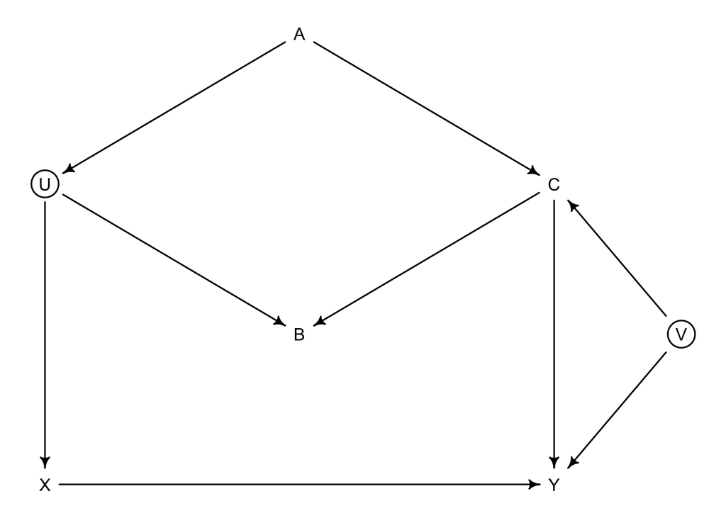

```r
library(dagitty)

dag_6M1<-dagitty("dag{
U[unobserved]
V[unobserved]
X->Y
X<-U->B<-C->Y
U<-A->C
C<-V->Y }")



coordinates(dag_6M1)<-list(x=c(X=0,Y=2,U=0,A=1,B=1,C=2,V=2.5),
                           y=c(X=2,Y=2,U=1,A=0.5,B=1.5,C=1,V=1.5))
drawdag(dag_6M1)
```

*There are 5 paths connecting X and Y:* (1) X → Y (the causal path) (2) X←U→B←C→Y (3) X←U→B←C←V→Y (4) X←U←A→C→Y (5) X←U←A→C←V→Y

*We want to leave path 1 open and make sure all of the others are closed, because they are non-causal paths that will confound inference. As before, all the paths through B are already closed, since B is a collider. So we don’t condition on B. Similarly, the new paths through both A and V are closed, because C is a collider on those paths. So it’s enough to condition on A to close all non-causal paths. If you like, you can check using dagitty:*

```r
 adjustmentSets( dag_6M1 , exposure="X" , outcome="Y" )
```

```
## { A }
```

10. 6M3. Learning to analyze DAGs requires practice. For each of the four DAGs below, state which variables, if any, you must adjust for (condition on) to estimate the total causal influence of X on Y. (SEE ILLUSTRATIONS OF DAGS IN BOOK WITH PROBLEM 6M3)

*In each case, the procedure is the same: List all paths between X and Y and figure out which non-causal paths are open and which variables you can use to close them. We’ll consider each in turn.*

*Top left. There are three paths between X and Y:* (1) X → Y,(2) X ← Z → Y,(3)X ← Z ← A → Y. *Both (2) and (3) are open, non-causal paths. Conditioning on Z is sufficient to close both.*

*Top right. Again three paths:* (1)X → Y,(2)X → Z → Y,(3)X → Z ← A → Y. Paths (1) and (2) are both causal. We want both open. Path (3) is non-causal, but it is also closed already because Z is a collider on that path. So no conditioning.

Bottom left. Paths: (1) X → Y,(2) X → Z ← Y,(3) X ← A → Z ← Y. Only path (1) is causal. The other paths are both closed, because both contain a collider at Z. Conditioning on Z would be a disaster. So no conditioning.

Bottom right. Paths: (1) X → Y,(2) X → Z → Y,(3) X ← A → Z → Y. Paths (1) and (2) are causal. Path (3) is an open backdoor path. To close it, we must condition on A or Z, but if condition on Z, that would close a causal path. So condition on A.

11. CHALLENGE. 6H1. Use the Waffle House data, data(WaffleDivorce), to find the total causal influence of number of Waffle Houses on divorce rate. Justify your model or models with a causal graph.

*How hard this is depends upon the DAG you draw. Here is one possibility.*

```r
data(WaffleDivorce)
head(WaffleDivorce)
```

```
##     Location Loc Population MedianAgeMarriage Marriage Marriage.SE Divorce
## 1    Alabama  AL       4.78              25.3     20.2        1.27    12.7
## 2     Alaska  AK       0.71              25.2     26.0        2.93    12.5
## 3    Arizona  AZ       6.33              25.8     20.3        0.98    10.8
## 4   Arkansas  AR       2.92              24.3     26.4        1.70    13.5
## 5 California  CA      37.25              26.8     19.1        0.39     8.0
## 6   Colorado  CO       5.03              25.7     23.5        1.24    11.6
##   Divorce.SE WaffleHouses South Slaves1860 Population1860 PropSlaves1860
## 1       0.79          128     1     435080         964201           0.45
## 2       2.05            0     0          0              0           0.00
## 3       0.74           18     0          0              0           0.00
## 4       1.22           41     1     111115         435450           0.26
## 5       0.24            0     0          0         379994           0.00
## 6       0.94           11     0          0          34277           0.00
```

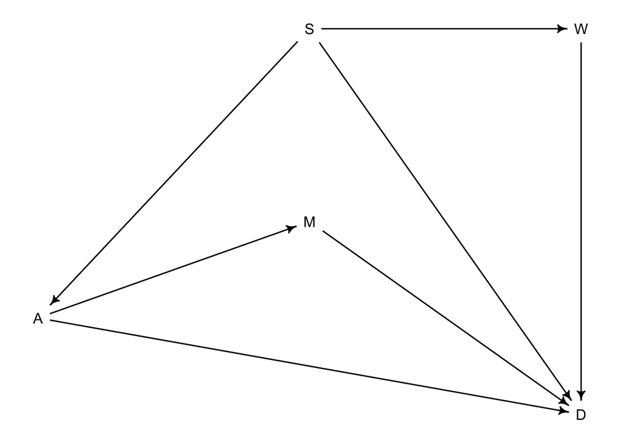

```r
library(dagitty)
dag_6H1 <- dagitty("dag{A -> D; A -> M -> D; A <- S -> D; S -> W -> D}")
coordinates(dag_6H1) <- list(
    x=c(A=0,M=1,D=2,S=1,W=2),
y=c(A=0.75,M=0.5,D=1,S=0,W=0) )
drawdag(dag_6H1)
```

*Given this DAG, you can probably see that all we need to control for is S, an indicator for southern States. This is needed to block the backdoor paths through the other variables.*

*It’s very likely that there are unobserved variables that confound this inference. For example, if Waffle House tends to build in places where it is cheap to operate, then there are economic confounds that might influence both the presence of Waffle Houses and divorce rate. In that case, we’d need to measure those confounds to get an inference. Lots of social scientists believe that it is usually impossible to measure all the probably confounds in these studies. They look for natural or quasi- experiments instead.*